# ejercicios

## Requisitos Generales para Todos los Ejercicios

- **Implementa tus soluciones usando Funciones**
- **Usen PYTHON PURO en la primera parte** (sin importar librerías externas como NumPy, SciPy, etc.)
- Validen los parámetros de entrada cuando lo consideren sea necesario
- Incluyan docstrings en cada función explicando su propósito
- Prueben cada función con ejemplos después de implementarla
- Comenten tu código para explicar la lógica principal cuando sea necesario

**Importante!!!** Deben entregar esta notebook completa en la fecha mencionada en clases, a través del aula virtual.

Ejemplo de validación:

```
def funcion(num):
    # esta función necesita que num sea menor a 10
    if num >= 10:
        raise ValueError("num' debe ser menor a 10")
    ...
```

# Parte 1: Python Puro

## Ejercicio: Sucesión de Fibonacci

Implementa una función que devuelva una lista con los primeros `n` términos de la sucesión de Fibonacci.

**Especificaciones:**

- Define una función llamada `fibonacci(n)` que reciba un número entero no negativo como parámetro y devuelva una lista con n elementos.
- La función debe validar que n sea mayor o igual a 0.
- Los primeros dos números de la secuencia son 0 y 1.
- Los siguientes términos de la secuencia son el resultado de sumar los dos anteriores.
- Utiliza **Python puro** sin librerías externas
- Optimiza la solución (preferentemente evitar recursión sin memoización para valores grandes)

```python
# Hacer
def fibonacci(n):
    Lista = [0, 1]
    if n>=0:
        for i in range(n):
            Lista.append(Lista[i+1]+Lista[i])
    return Lista

nuevaLista = fibonacci(6)
print(nuevaLista)
```

```
[0, 1, 1, 2, 3, 5, 8, 13]
```

## Ejercicio: Factorial

Implementa una función que calcule el factorial de un número entero.

**Especificaciones:**

- Define una función llamada `factorial(n)` que reciba un número entero positivo como parámetro
- La función debe validar que el número sea mayor o igual a 0
- Retorna el factorial de n (n! = n × (n-1) × (n-2) × ... × 1)
- Utiliza **Python puro** sin librerías externas
- Intenten hacer dos versiones: con bucles y con recursión

**Ejemplo:** `factorial(5)` deberá retornar `120` (5*4*3*2*1)

```python
# Hacer
def factorial(n):
    if n >= 0:
        if n > 0:
            return n*factorial(n-1)
        else :
            return 1
    return n

def factorial2(n):
    if n >= 0:
        num = 1
        while n > 1:
            num *= n
            n = n-1
        return num
    return n

print(f"Resultado de Factorial en bucle de 5 = {factorial2(5)} | Resultado de Factorial en recursiva de 5 = {factorial(5)}")
```

```
Resultado de Factorial en bucle de 5 = 120 | Resultado de Factorial en recursiva de 5 = 120
```

## Ejercicio: Producto Escalar de Dos Vectores

Implementa una función que calcule el producto escalar (dot product) de dos vectores.

**Especificaciones:**

- Define una función llamada `producto_escalar(vector1, vector2)` que reciba dos listas como parámetros
- La función debe validar que ambos vectores tengan la misma longitud
- Retorna el resultado del producto escalar (suma de los productos de los elementos correspondientes)
- Utiliza **Python puro** (sin librerías externas como NumPy)
- Implementa la lógica usando únicamente funciones y estructuras básicas de Python

**Ejemplo:** `producto_escalar([1, 2, 3], [4, 5, 6])` deberá retornar `32` `(1*4 + 2*5 + 3*6)`

```python
# Hacer
def producto_escalar(vector1, vector2):
    if len(vector1) == len(vector2):
        producto = 0
        i = 0
        while i < len(vector1):
            producto += (vector1[i] * vector2[i])
            i = i+1
        return producto
    return 0

print(producto_escalar([1, 2, 3], [4, 5, 6]))
```

```
32
```

## Ejercicio: Norma de un Vector

Implementa una función que calcule la norma (magnitud) de un vector.

**Especificaciones:**

- Define una función llamada `norma(vector)` que reciba una lista como parámetro
- La norma euclidiana (vista en algebra lineal) se calcula como: ||v|| = √(v₁² + v₂² + ... + vₙ²)
- Retorna el valor de la norma
- Utiliza **Python puro** sin librerías externas
- Tu función principal `norma()` debe usar la norma euclidiana por defecto

**Ejemplo:** `norma([3, 4])` deberá retornar `5.0`

```python
# Hacer
def norma(vector):
    suma = 0
    for i in range(len(vector)):
        suma += vector[i]**2
    return suma**0.5

print(norma([3, 4]))
```

```
5.0
```

## Ejercicio: Divisores de un número

Implemente una función que reciva un número y devuelva una lista con sus divisores.

**Especificaciones**:

- Los divisores de un número son aquellos números enteros que lo dividen de forma exacta, es decir, sin dejar residuo o resto cero.
- Defina una función llamada `encontrar_divisores(num)` que reciba un número y devuelva una tupla o lista.
- Los divisores siempre inlcuyen al 1 y al número en cuestión.

**Ejemplo**: `encontrar_divisores(10)` deberá retornar `(1, 2, 5, 10)`

```python
# Hacer
def encontrar_divisores(num):
    if num == 0 : return num  # Experimentando con la tipografia(0 escritura o como se diga) de python
    divisores = []
    for i in range(num):
        if (num % (num-i)) == 0:
            divisores.append(num//(num-i))
    return divisores

nuevaList = encontrar_divisores(10)
print(nuevaList)
```

```
[1, 2, 5, 10]
```

## Ejercicio: Es primo

Implemente una función que reciva un número y devuelva un booleano indicando si es primo.

**Especificaciones**:

- Los números primos son aquellos que solo se pueden dividir entre 1 y sí mismos.
- Defina una función llamada `es_primo(num)` que reciba un número y devuelva una booleano.

**Ejemplo**: `es_primo(5)` deberá retornar `True`

```python
# Hacer
def es_primo(num):
    if num <= 0 : return False
    contador = 0
    for i in range(num):
        if (num%(i+1))==0:
            contador += 1
    if contador==2 : return True
    return False

print(es_primo(5))
```

```
True
```

# Parte 2. Utilizando Librerias (numpy y matplotlib)

```python
import numpy as np
# Crear un arreglo de 10 números aleatorios entre 0 y 1
arreglo = np.random.rand(10)
print(arreglo)
```

```
[0.64321627 0.20197969 0.86206703 0.30799249 0.80538862 0.12350995
 0.88628327 0.93895256 0.80176576 0.38210655]
```

```python
import numpy as np
# Crear un arreglo de 12 numeros entre 0 y 1.
arreglo2 = np.random.rand(12)

# Luego convertirlo en una matriz de 3 filas y 4 columnas
matriz = arreglo2.reshape(3, 4)
print(matriz)
```

```
[[0.24966897 0.61604471 0.36682845 0.51126165]
 [0.58319762 0.85144966 0.99400199 0.55115798]
 [0.69033911 0.22805417 0.78305155 0.52895074]]
```

```python
import numpy as np

# Dada el siguiente arreglo:
arr = np.array([1, 2, 0, 0, 5, 0])

# imprimir solo los valores no nulos del arreglo **sin usar bucles!**
sin_nulo = arr[arr != 0]
print(sin_nulo)
```

```
[1 2 5]
```

```python
import numpy as np

# Dada la siguiente matriz:
mat = np.array([[1, 2, 3], [4, 5, 6], [7, 8, 9]])
print(mat)
print("- - - - -")

# Imprima los primeros 2 renglones y las últimas 2 columnas de la matriz
nueva_matriz = mat[0:2, 1:3]
print(nueva_matriz)
```

```
[[1 2 3]
 [4 5 6]
 [7 8 9]]
- - - - -
[[2 3]
 [5 6]]
```

## Ejercicio: Distancia entre Dos Puntos

Implementa una función que calcule la distancia euclideana entre dos puntos en un espacio n-dimensional.

**Especificaciones:**

- Define una función llamada `distancia(punto1, punto2)` que reciba dos puntos como listas/tuplas
- La función debe validar que ambos puntos tengan la misma dimensión
- Calcula la distancia usando la fórmula: d = √((x₂-x₁)² + (y₂-y₁)² + ... + (nₙ-n₁)²)
- Retorna la distancia como un número real
- Haz dos versiones:
  - La primera con **Python puro** sin librerías externas como NumPy
  - En la segunda utiliza numpy para simplificar la función

**Ejemplo:** `distancia([0, 0], [3, 4])` deberá retornar `5.0`

```python
# hacer
import numpy as np
def distancia(punto1, punto2):
    if len(punto1) != len(punto2): return "Los puntos deben tener la misma dimensión"
    suma = 0
    for i in range(len(punto1)):
        suma += (punto2[i] - punto1[i])**2
    return (suma**0.5)

def distanciaV2(punto1, punto2):
    p1 = np.array(punto1)
    p2 = np.array(punto2)
    if p1.shape != p2.shape:
        raise ValueError("Los puntos deben tener la misma dimensión")

    return np.linalg.norm(p2 - p1)


print(distancia([0, 0],[3, 4]))
print("- - - - ")
print(distanciaV2([0, 0],[3, 4]))
```

```
5.0
- - - -
5.0
```

## Ejercicio: Distribución Tiradas de dados

**Notas:**

- utilice el módulo random de numpy (`numpy.random`) para generar las `N` tiradas.
- Use la función `plt.hist()` para graficar. Especifique el número de `bins` según corresponda (`plt.hist(tiradas, bins=6)`).

[output not shown]

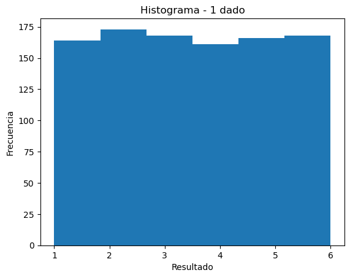

```python
# hacer
import numpy as np
import matplotlib.pyplot as plt

N = 1000
tiradas = np.random.randint(1, 7, size=N)

plt.hist(tiradas, bins=6)
plt.title("Histograma - 1 dado")
plt.xlabel("Resultado")
plt.ylabel("Frecuencia")
plt.show()
```

## Ejercicio: Mensaje de Arecibo

El [mensaje de Arecibo](https://en.wikipedia.org/wiki/Arecibo_message) es un conocido experimento en el cual se envió un mensaje en binario al espacio exterior. En este ejercicio deberan leer un archivo con el mensaje y mostrarlo de forma adecuada.

- Deberá cargar el archivo `arecibo.npy` usando numpy.
- Debe encontrar un número de filas y columnas adecuado para convertir el arreglo en matriz (anteriormente hizó una función que le puede servir para esto)
- Una vez que tenga la matriz, puede graficarla usando la función `plt.imshow(matriz)` de matplotlib.

```
Cantidad de elementos: 1679
Filas: 23
Columnas: 73
```

[figure not shown]

```python
# Lea el archivo "arecibo.npy" utilizando numpy
import numpy as np
import matplotlib.pyplot as plt

arr = np.load("arecibo.npy")

# Imprima el número de filas y columnas del arreglo cargado

print("Cantidad de elementos:", arr.shape[0])
filas = 23
columnas = 73
# use la función reshape para convertir el arreglo en una matriz
# (debe encontrar el número de filas y columnas primero)
matriz = arr.reshape(filas, columnas)
# Imprima el número de filas y columnas de la nueva matriz
print("Filas:", matriz.shape[0])
print("Columnas:", matriz.shape[1])
# use la función plt.imshow para mostrar la matriz como una imagen
# (asegúrese de importar matplotlib.pyplot como plt)
plt.imshow(matriz, cmap='binary')
plt.title("Mensaje de Arecibo")
plt.show()
```